# Lab 12: Elasticity — What the Coefficient Means, and What It Costs to Get Wrong

ECON 8310: Business Forecasting — University of Nebraska at Omaha

# What we are doing

A Bayesian regression coefficient is a distribution, and a price elasticity is the one number a category manager will actually act on. Today you will estimate one, and then find three separate ways it can be wrong while every diagnostic still says the model is fine.

Two of the three are not statistical failures at all. One is a routine preprocessing step you have used in every lab since Lecture 6.

**Suggested time:** ~45 minutes · **You will need:** `pandas`, `numpy`, `matplotlib`, `pymc`, `arviz`, and `data/processed/m5_weekly.csv`. Three model fits, most under 30 seconds.

# Setup

```python
import pandas as pd
import numpy as np
import matplotlib.pyplot as plt
import pymc as pm
import arviz as az
import warnings

warnings.filterwarnings("ignore")
RANDOM_STATE = 42

weekly = pd.read_csv("../data/processed/m5_weekly.csv", parse_dates=["week_start"])
weekly["series"] = weekly.store_id + "_" + weekly.cat_id

df = weekly.dropna(subset=["units", "avg_price"]).copy()
df = df[df.avg_price > 0]
df["ly"]    = np.log(df.units.clip(lower=1))
df["lp"]    = np.log(df.avg_price)
df["snap"]  = (df.snap_days >= 5).astype(float)
df["event"] = (df.event_days > 0).astype(float)
df["yr"]    = (df.week_start - df.week_start.min()).dt.days / 365.25

codes, uniq = pd.factorize(df.series)
df["idx"] = codes
J = len(uniq)
y = df.ly.values

print(f"{len(df):,} rows | {J} series | sd(log price) = {df.lp.std():.4f}")
```

```
8,310 rows | 30 series | sd(log price) = 0.2444
```

With units and price both in logs, the price coefficient is an **elasticity**: the percent change in demand per percent change in price. Hold on to that sentence — Step 3 is about the moment it stops being true.

One model function, with switches for the three things we want to vary.

```python
def fit(price_col, controlled=True, standardize_price=False, seed=RANDOM_STATE):
    x = df[price_col].values.astype(float)
    if standardize_price:
        x = (x - x.mean()) / x.std()
    with pm.Model():
        s  = pm.Exponential("sigma", 1.0)
        bp = pm.Normal("b_price", 0, 1)
        bs = pm.Normal("b_snap",  0, 1)
        be = pm.Normal("b_event", 0, 1)
        if controlled:
            a  = pm.Normal("a", y.mean(), 1, shape=J)
            bt = pm.Normal("b_trend", 0, 1)
            mu = (a[df.idx.values] + bp * x + bs * df.snap.values
                  + be * df.event.values + bt * df.yr.values)
        else:
            a  = pm.Normal("a", y.mean(), 1)
            mu = a + bp * x + bs * df.snap.values + be * df.event.values
        pm.Normal("obs", mu=mu, sigma=s, observed=y)
        return pm.sample(1000, tune=1500, chains=4, progressbar=False,
                         random_seed=seed, target_accept=0.9)

def show(idata, controlled=True, label=""):
    vs = ["b_price", "b_snap", "b_event"] + (["b_trend"] if controlled else [])
    su = az.summary(idata, var_names=vs, ci_kind="hdi", ci_prob=0.94, round_to=4)
    print(label)
    print(su[["mean", "hdi94_lb", "hdi94_ub", "r_hat", "ess_bulk"]].to_string())
    return su
```

# Step 1 — The naive elasticity

Regress log units on log price, SNAP and events. Nothing else.

```python
idata_naive = fit("lp", controlled=False)
_ = show(idata_naive, controlled=False, label="Naive")
```

```
Naive
           mean  hdi94_lb  hdi94_ub   r_hat   ess_bulk
b_price -2.8048   -2.8556   -2.7559  1.0018  2321.0850
b_snap   0.0543    0.0254    0.0830  1.0009  3699.7362
b_event -0.0109   -0.0355    0.0139  1.0001  3914.5966
```

An elasticity near $-2.8$: a 1% price rise costs almost 3% of volume. Diagnostics are clean, $\hat{R}$ is 1.00, ESS is in the thousands, and the interval is tight.

It is also badly wrong, and Lecture 12’s DAG says why before any model is fitted. Our thirty series are different categories in different stores. Categories differ systematically in **both** typical price and typical volume — HOBBIES items cost more per unit and sell fewer of them. So series identity is an arrow into price *and* into units: a textbook confounder.

Comparing a hobby item to a food item is not measuring a price response. It is measuring the difference between two product categories.

# Step 2 — Control for the confounder

Add per-series intercepts and a trend. The trend is there because time is a second confounder: prices and volumes both rose over 2011–2016, so later weeks are dearer *and* busier. The series intercepts remove the between-series confounding, so the price coefficient uses only variation *inside* a series over time — which is the variation a manager could actually create. Centering log price within each series leaves the coefficient unchanged and makes the sampler’s job easier.

```python
df["lpc"] = df.lp - df.groupby("series").lp.transform("mean")

idata_ctrl = fit("lpc", controlled=True)
su_ctrl = show(idata_ctrl, label="Controlled")
```

```
Controlled
           mean  hdi94_lb  hdi94_ub   r_hat   ess_bulk
b_price -0.4931   -0.5963   -0.3872  1.0017  3096.7013
b_snap   0.0364    0.0271    0.0458  1.0003  7253.6068
b_event -0.0035   -0.0109    0.0040  1.0012  4987.5263
b_trend  0.1095    0.1065    0.1125  1.0034  1923.0836
```

```python
b_naive = idata_naive.posterior["b_price"].values.ravel()
b_ctrl  = idata_ctrl.posterior["b_price"].values.ravel()

print(f"  naive       {b_naive.mean():+.3f}   width of 94% HDI "
      f"{np.diff(az.hdi(b_naive, prob=0.94))[0]:.3f}")
print(f"  controlled  {b_ctrl.mean():+.3f}   width of 94% HDI "
      f"{np.diff(az.hdi(b_ctrl, prob=0.94))[0]:.3f}")
print(f"  the naive estimate is {b_naive.mean()/b_ctrl.mean():.1f}x too large")
```

```
  naive       -2.805   width of 94% HDI 0.099
  controlled  -0.493   width of 94% HDI 0.208
  the naive estimate is 5.7x too large
```

**Precision is not accuracy**

The naive estimate is nearly six times too large **and its interval is half the width**. It is not noisy. It is confidently, precisely wrong.

A tight credible interval says the model is sure. It says nothing about whether the model is answering your question — and no diagnostic in ArviZ will ever tell you that it isn’t. Only the DAG does.

```python
# ---- your turn: uncomment and answer in the string ----
# direction = "..."   # <- the naive estimate is too NEGATIVE. Which arrow in the DAG
#                     #    makes the bias run that way rather than the other?
# print(direction)
```

# Step 3 — The preprocessing step that silently destroys the answer

You have standardized predictors in nearly every lab since Lecture 6. It makes `Normal(0, 1)` priors mean the same thing across variables, and it helps samplers. It is a good habit.

Do it to log price here and watch what happens.

```python
idata_std = fit("lpc", controlled=True, standardize_price=True)
b_std = idata_std.posterior["b_price"].values.ravel()

print(f"  unstandardized  b_price = {b_ctrl.mean():+.4f}")
print(f"  standardized    b_price = {b_std.mean():+.4f}")
print(f"  sd(centered log price)   = {df.lpc.std():.4f}")
print(f"  ratio                   = {b_ctrl.mean()/b_std.mean():.4f}")
```

```
  unstandardized  b_price = -0.4931
  standardized    b_price = -0.0225
  sd(centered log price)   = 0.0455
  ratio                   = 21.9362
```

The two fits agree perfectly — they are the same model. But the *coefficient* is no longer the same quantity. Standardizing divided log price by its standard deviation, so the coefficient is now the change in log units per **standard deviation** of log price, not per percent.

Both diagnostics are clean. Both intervals exclude zero. Nothing anywhere reports a problem. The only thing that changed is what the number means, and the model has no way to tell you.

Now watch it become a business error.

```python
def scenario(b, pct=5.0):
    """Percent change in units, and in revenue, from a `pct` price rise."""
    units = 100 * (np.exp(b * np.log(1 + pct/100)) - 1)
    rev   = 100 * ((1 + pct/100) * np.exp(b * np.log(1 + pct/100)) - 1)
    return units, rev

for label, b in [("correct (elasticity)", b_ctrl), ("standardized", b_std)]:
    u, r = scenario(b)
    print(f"  {label:<22s} 5% price rise -> units {u.mean():+.2f}%  "
          f"revenue {r.mean():+.2f}%")
```

```
  correct (elasticity)   5% price rise -> units -2.38%  revenue +2.50%
  standardized           5% price rise -> units -0.11%  revenue +4.88%
```

**This is the lab’s point**

Read the two lines. Using the standardized coefficient, a manager is told a 5% price rise costs about a tenth of a percent of volume. The truth is **more than twenty times that** — because the coefficient was divided by the standard deviation of centered log price, which is only 0.0455. The revenue projection is inflated too, from $+2.5\%$ to $+4.9\%$.

The smaller the standard deviation you divide by, the larger the distortion. Here the within-series price variation is genuinely small, which makes the error enormous — and entirely invisible.

The model was right. The sampler was right. The diagnostics were right. The error entered through a preprocessing convenience three cells earlier, and it survived all the way to a stocking decision because **nothing downstream carries units**.

The habit that prevents it: write down what one unit of each variable *is* before you rescale it, and check that the coefficient still answers the question you asked.

```python
# ---- your turn: uncomment and fill in ----
# print("To recover the elasticity from the standardized fit, multiply it by ___")
```

# Step 4 — Ask the posterior a business question

The posterior is samples, so any question is answered by counting. Use the correct fit.

```python
print(f"  P(elasticity < 0)     = {(b_ctrl < 0).mean():.3f}")
print(f"  P(elasticity < -1)    = {(b_ctrl < -1).mean():.3f}")
print(f"  P(elasticity < -0.5)  = {(b_ctrl < -0.5).mean():.3f}")
```

```
  P(elasticity < 0)     = 1.000
  P(elasticity < -1)    = 0.000
  P(elasticity < -0.5)  = 0.460
```

The first number settles the direction: every posterior sample is negative, so demand falls when price rises. There is no doubt at all.

The second settles the question a pricing manager asks first. An elasticity of $-1$ is the boundary between **elastic** demand (below it, a price rise loses revenue) and **inelastic** demand (above it, a price rise gains revenue). Not one posterior sample is below $-1$: **demand is inelastic in every draw.**

The third is a finer question about size: does a 1% price rise cost more than half a percent of volume? Here the posterior is within a few points of a coin flip, and that is the honest report. The usual p-value, against zero, would have given only the direction.

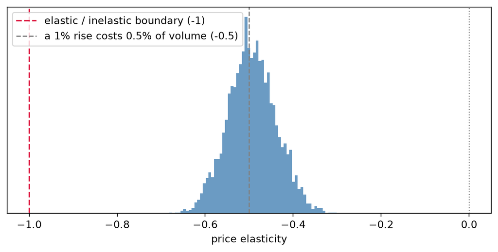

The full posterior, with the elastic / inelastic boundary and the finer threshold marked.

```python
fig, ax = plt.subplots(figsize=(7, 3.6))
ax.hist(b_ctrl, bins=60, color="steelblue", alpha=0.8)
ax.axvline(-1, color="crimson", ls="--", lw=1.5, label="elastic / inelastic boundary (-1)")
ax.axvline(-0.5, color="gray", ls="--", lw=1.2, label="a 1% rise costs 0.5% of volume (-0.5)")
ax.axvline(0, color="gray", ls=":", lw=1)
ax.set_xlabel("price elasticity"); ax.set_yticks([])
ax.legend(); plt.tight_layout(); plt.show()
```

Now the decision the manager actually faces.

```python
u5, r5 = scenario(b_ctrl, 5.0)
print(f"  5% price rise:  units {u5.mean():+.2f}%  "
      f"[{np.percentile(u5,3):+.2f}, {np.percentile(u5,97):+.2f}]")
print(f"                  revenue {r5.mean():+.2f}%  "
      f"[{np.percentile(r5,3):+.2f}, {np.percentile(r5,97):+.2f}]")
print(f"  P(revenue rises) = {(r5 > 0).mean():.3f}")
```

```
  5% price rise:  units -2.38%  [-2.87, -1.87]
                  revenue +2.50%  [+1.99, +3.03]
  P(revenue rises) = 1.000
```

Revenue rises with probability 1.00 across every posterior sample, and the second probability above says why: a 5% rise multiplies revenue by $1.05^{\,1+b}$, which is above one exactly when the elasticity $b$ is above $-1$, and every draw is. The finer size question stays open while the decision is settled. Only the posterior lets you say both.

```python
# ---- your turn: uncomment and answer in the strings ----
# recommend = "..."   # <- two sentences to the manager, with a probability attached
# caveat    = "..."   # <- name one DAG arrow that, if wrong, invalidates this
# print(recommend); print(caveat)
```

# Before you leave

> **Discuss (the three failures):** This lab met three ways an elasticity analysis goes wrong — an omitted confounder, a rescaled coefficient, and a size question the data cannot settle. Which of the three would any ArviZ diagnostic have caught? What does your answer imply about what diagnostics are for?

> **Discuss (the habit):** Standardizing is genuinely good practice and you should keep doing it. State the rule that lets you keep the habit without repeating Step 3’s error.

> **Discuss (the decision):** You must advise on the 5% rise using only Step 4’s output. Write the recommendation. Then say what you would want measured before a 20% rise, and why extrapolating this elasticity that far is a different kind of claim.

> **Discuss (the course):** You have now estimated the same kind of quantity with OLS, XGBoost, and a Bayesian regression. Only one of them naturally answers “how likely is it that revenue rises?” Explain what about the Bayesian output makes that question cheap, and name one forecasting task from this course where you would still not reach for it.

*Solutions posted to Canvas after class.*